# Your Digest for Sunday, Oct 08, 2023 11:59 PM

- Everyone has a physiological tremor of 8-12 Hz which is enhanced by anxiety, caffeine, hyperthyroidism and drugs. Benign essential tremor is not exacerbated by caffeine.
- The amplitude of this is increased in **Benign essential tremor.**
  - Titubation - thymic up and down or side to side head movements.

Use this note as a card in the canvas.

## Manifestations of CKD-MBD

CKD-mineral bone disease = hyperparathyroid bone disease = osteoporosis, osteomalacia, osteoscleroris, adynamic bone disease.  
Basically, CKD patients have **mixed bone disease.**

Almost universal upon development of Stage III (i.e eGFR >= 30)

In addition to bone manifestations, ?metastatic calcification due to stimulation of endothelial cells to take own an osteoblast like phenotypes, so that they deposit calcified matrix.

- Result is calcification of arteries -> hypertension and LVH
- Calcification of heart valves

## Pathogenesis of CKD-MBD

Phosphate excretion is handled by the kidney and resorption of filtered phosphate is a passive process, most occurring in the PCT.

- *Phosphate excretion falls*, very early on in CKD.
- To counteract this, osteocytes release FGF23 which promotes phosphaturia and reduces activation of vitamin D, thereby decreasing gut absorption of phosphate.

> [!INFO] **Elevated FGF23** levels are the *strongest independent predictor* of mortality in patients with CKD.

but as CKD progresses, this compensation is overcome.

> [!INFO] Osteoporosis Vs. Osteomalacia

Osteomalacia

Osteoporosis

Imparment of mineralization

Mineral content is normal

matrix deposition in tact

Total bone mass decreased

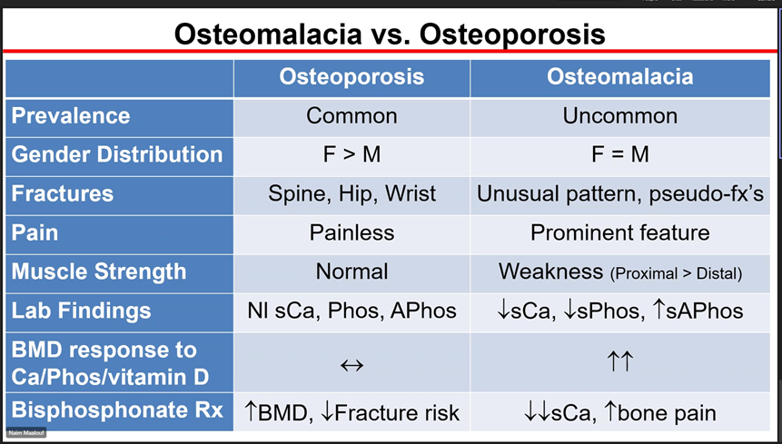

From an unverified twitter source.

#2020SBR-NOV/Q10

# SVT and management

#2020SBR-NOV/Q10  
See this pdf: [[SVTAndManagement.pdf]]

[output not shown]

# 9: Lithium

**Indications**:  
Lithium is used for prophylaxis of mania in bipolar patients. Not for acute treatment. For acute mania, antipsychotics and *antiepileptics* are equally effective.

**Pharmacology**

- Very narrow therapeutic window. (therapeutic range is 0.5 to 1mmol/L and toxic effects start at 1.5 mmol/L)
- It passes into cells via the sodium channels but is not pumped out via Na/K ATPase so accumulates within neurons.
- Lithium preferentially affects organs with lots of sodium channels : I.e *Brain and kidney and thyroid.*
- Exact mechanism of action is a mystery
- Half of the oral dose is eliminated quickly by the kidneys. The rest is eliminated slowly over 2 weeks.
- Therefore, it takes about **1 week for steady state concentrations**. (Bennet and brown : 5 - 6 days, Rang and Dale : 1 - 2 weeks)
  - Lithium levels can be increased by hyponatremia because "the kidney treats lithium and sodium similarly and hyponatremia will cause increased lithium reabsorption" in the proximal tubule.
  - Diuretics acting distal to the PCT have a similar effect.
- **Toxicity**:
  - Side effects occuring at therapeutic range: Fine tremor, polyuria, polydypsia, metallic taste, goiter, hypothyroidism,
  - Moderate toxicity : (plasma level > 1.5mmo/L) - **GI**: N/V/D and **neuromuscular**: *Course* tremor, weakness, ataxia, blurred vision
  - Severe toxicity: Medical emergency: hyperreflexia, hyperextension of limbs, convulsions, syncope and death.
  - **Management of acute toxicity**: improve renal elimination or dialysis (but dialysis only removes the plasma content. Cellular content is slow to shift to the plasma)
  - Drugs interfering with renal excretion of lithium: Thiazides > loop diuretics, ACEi, ARB, NSAIDS,

Dyslipidaemia

## Physiology: Lipid transport in the blood

Disorders causing isolated elevations in LDL and VLDL only are also somewhat common.

> This is reported by the lab as
> $$
> Total\space cholesterol - HDL\space cholesterol
> $$

## Normal levels for serum lipids

[output not shown]

Patients are **not actually hypovolemic.**

> [!INFO] The types of diuretics are

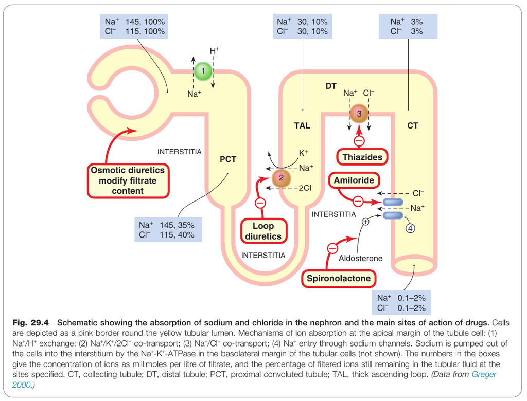

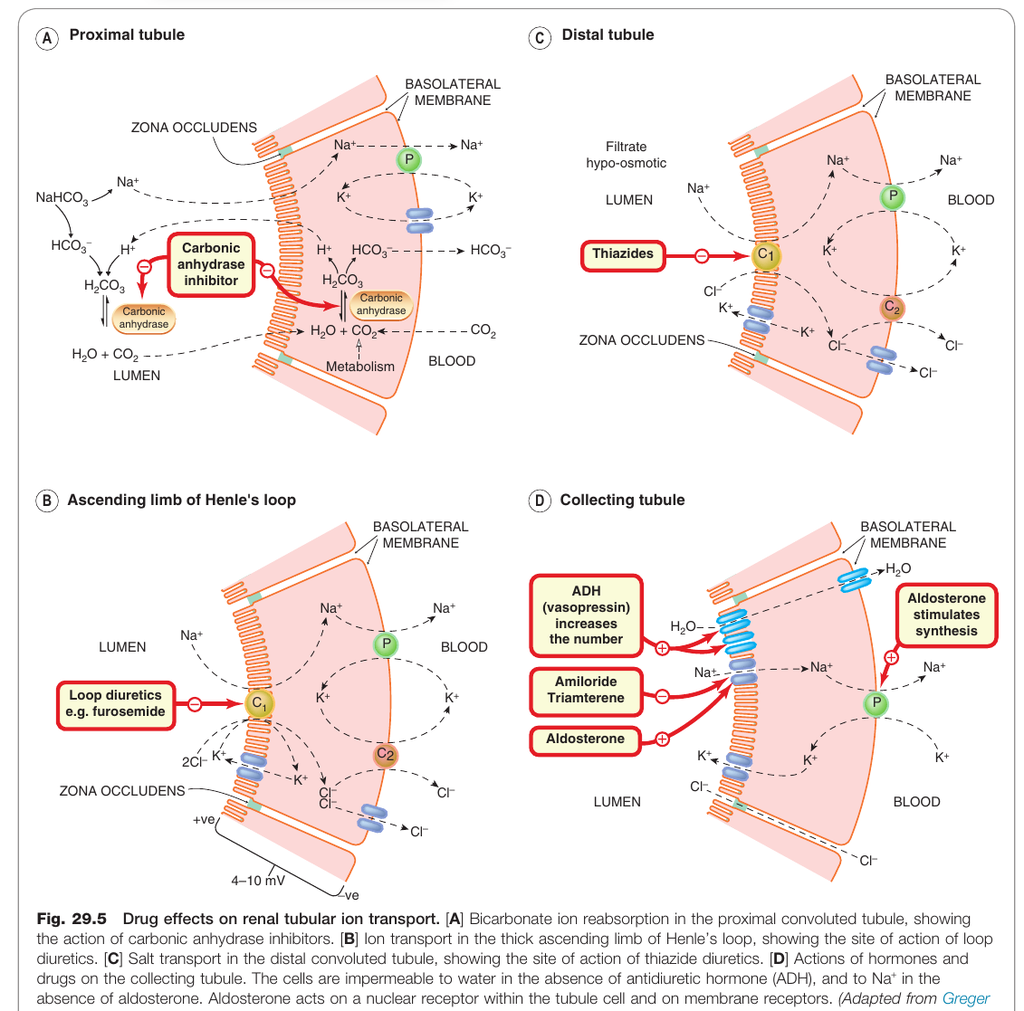

Therefore, if a patient is not stabilizing after adequate fluid therapy and vasopressor (defined as >0.25mcg/Kg/min norad for More than 4 hours for the purposes of relevant research), *IV hydrocortisone 200mg day* as 4 divided doses can be given.

[output not shown]